# Проект: Предсказание оттока клиентов телеком компании

**Описание задачи**  
Оператор связи «ТелеДом» сталкивается с проблемой оттока клиентов, что негативно влияет на доходы компании. Чтобы минимизировать убытки, компания планирует внедрить систему персонализированных предложений (промокоды, скидки, специальные условия) для клиентов, склонных к расторжению договора.

**Цель проекта** — разработать модель машинного обучения, которая предсказывает, разорвёт ли клиент договор с оператором. Для обучения модели используются данные о персональных характеристиках клиентов, их тарифах, подключенных услугах и исторических платежах.

**Ключевые этапы работы:**

1. Загрузка и анализ данных из четырёх источников.
2. Объединение данных в единый датафрейм.
3. Предобработка данных (обработка пропусков).
4. Исследовательский анализ данных (выявление закономерностей, корреляций).
5. Подготовка данных для машинного обучения.
6. Обучение и сравнение нескольких моделей.
7. Подбор гиперпараметров для выбранной модели.
8. Оценка качества модели на тестовой выборке.
9. Анализ и интерпретация важности признаков.
10. Анализ и интерпретация матрицы ошибок.
11. Итоговый вывод и формулировка рекомендаций для бизнеса.

**Исходные данные:**

Данные предоставлены в четырёх файлах:

1. **contract_new.csv** — информация о договоре.
2. **personal_new.csv** — персональные данные клиента.
3. **internet_new.csv** — информация об интернет-услугах.
4. **phone_new.csv** — информация об услугах телефонии.

Описание датасетов:  
**Датасет `contract_new.csv`**

- `customerID` — уникальный идентификатор абонента.
- `BeginDate` — дата начала действия договора.
- `EndDate` — дата окончания договора (нет или дата).
- `Type` — тип оплаты: раз в год-два или ежемесячно.
- `PaperlessBilling` — электронный расчётный лист (да/нет).
- `PaymentMethod` — способ оплаты.
- `MonthlyCharges` — ежемесячные расходы клиента.
- `TotalCharges` — общие расходы за весь период.

**Датасет `personal_new.csv`**

- `customerID` — уникальный идентификатор клиента.
- `gender` — пол клиента (мужской/женский).
- `SeniorCitizen` — является ли клиент пенсионером (1/0).
- `Partner` — есть ли у абонента супруг или супруга (да/нет).
- `Dependents` — наличие детей (да/нет).

**Датасет `internet_new.csv`**

- `customerID` — уникальный идентификатор клиента.
- `InternetService` — тип подключения интернета (DSL, Fiber optic).
- `OnlineSecurity` — блокировка опасных сайтов (да/нет).
- `OnlineBackup` — облачное хранилище для резервного копирования (да/нет).
- `DeviceProtection` — антивирус (да/нет).
- `TechSupport` — выделенная линия техподдержки (да/нет).
- `StreamingTV` — стриминговое телевидение (да/нет).
- `StreamingMovies` — каталог фильмов (да/нет).

**Датасет `phone_new.csv`**

- `customerID` — уникальный идентификатор клиента.
- `MultipleLines` — подключение телефона к нескольким линиям одновременно (да/нет).

Особенности данных:

- **Объединение по ключу:** Все файлы связаны через столбец `customerID`.
- **Целевая переменная:** Определяется на основе столбца `EndDate`:
  - Если `EndDate` заполнен — клиент ушёл (1).
  - Если `EndDate` = No — клиент остался (0).

## Загрузка и Предобработка данных

```python
!pip install -q phik
!pip install -q catboost
```

```
   ━━━━━━━━━━━━━━━━━━━━━━━━━━━━━━━━━━━━━━━━ 687.8/687.8 kB 6.0 MB/s eta 0:00:00
   ━━━━━━━━━━━━━━━━━━━━━━━━━━━━━━━━━━━━━━━━ 99.2/99.2 MB 4.2 MB/s eta 0:00:00
```

```python
# Выполним загрузку необходимых библиотек
import pandas as pd
import numpy as np
import matplotlib.pyplot as plt
import seaborn as sns
import phik

from google.colab import drive
from sklearn.model_selection  import train_test_split, RandomizedSearchCV
from sklearn.pipeline import Pipeline
from sklearn.compose import ColumnTransformer
from sklearn.impute import SimpleImputer
from sklearn.preprocessing import OneHotEncoder, MinMaxScaler, StandardScaler
from sklearn.linear_model import LogisticRegression
from sklearn.tree import DecisionTreeClassifier
from sklearn.metrics import roc_auc_score, accuracy_score, confusion_matrix
from catboost import CatBoostClassifier

RANDOM_STATE=20625
```

```python
pd.set_option('display.max_columns', None)
pd.set_option('display.max_rows', None)
drive.mount('/content/drive')
```

Выпоним загрузку данных.

```python
try:
    contract = pd.read_csv('/datasets/contract_new.csv')  # Для практикума
    personal = pd.read_csv('/datasets/personal_new.csv')
    internet = pd.read_csv('/datasets/internet_new.csv')
    phone    = pd.read_csv('/datasets/phone_new.csv')
except FileNotFoundError:
    try:
        contract = pd.read_csv('Модуль 5 выпускной проект/contract_new.csv')  # Если файл локальный
        personal = pd.read_csv('Модуль 5 выпускной проект/personal_new.csv')
        internet = pd.read_csv('Модуль 5 выпускной проект/datasets/internet_new.csv')
        phone    = pd.read_csv('Модуль 5 выпускной проект/datasets/phone_new.csv')
    except FileNotFoundError:
        try:
            contract = pd.read_csv('/content/drive/MyDrive/Colab Notebooks/Модуль 5/contract_new.csv')  # Для Google Colab
            personal = pd.read_csv('/content/drive/MyDrive/Colab Notebooks/Модуль 5/personal_new.csv')
            internet = pd.read_csv('/content/drive/MyDrive/Colab Notebooks/Модуль 5/internet_new.csv')
            phone    = pd.read_csv('/content/drive/MyDrive/Colab Notebooks/Модуль 5/phone_new.csv')
        except FileNotFoundError:
            print('Файл не найден ни в одном из указанных мест.')
            contract = None
```

Выполним первичный анализ данных.

```python
# Функция для анализа данных
def first_check(df, data_name=''):
    if data_name:
        print(f'Анализ датасета: {data_name}')
    else:
        print(f'Анализ датасета:')
    print("=" * 40 + "\n")

    print('Первые 5 строк:')
    display(df.head())
    print('\nПоследние 5 строк:')
    display(df.tail())
    print('\nРазмерность датасета:')
    print(df.shape)
    print('\nИнформация о типах данных и пропусках:')
    print(df.info())
    print('\nОписательная статистика:')
    display(df.describe(include='all'))
```

```python
first_check(contract, data_name='contract')
```

```
Анализ датасета: contract
========================================

Первые 5 строк:
```

|  | customerID | BeginDate | EndDate | Type | PaperlessBilling | PaymentMethod | MonthlyCharges | TotalCharges |
| --- | --- | --- | --- | --- | --- | --- | --- | --- |
| 0 | 7590-VHVEG | 2020-01-01 | No | Month-to-month | Yes | Electronic check | 29.85 | 31.04 |
| 1 | 5575-GNVDE | 2017-04-01 | No | One year | No | Mailed check | 56.95 | 2071.84 |
| 2 | 3668-QPYBK | 2019-10-01 | No | Month-to-month | Yes | Mailed check | 53.85 | 226.17 |
| 3 | 7795-CFOCW | 2016-05-01 | No | One year | No | Bank transfer (automatic) | 42.30 | 1960.6 |
| 4 | 9237-HQITU | 2019-09-01 | No | Month-to-month | Yes | Electronic check | 70.70 | 353.5 |

```
Последние 5 строк:
```

|  | customerID | BeginDate | EndDate | Type | PaperlessBilling | PaymentMethod | MonthlyCharges | TotalCharges |
| --- | --- | --- | --- | --- | --- | --- | --- | --- |
| 7038 | 6840-RESVB | 2018-02-01 | No | One year | Yes | Mailed check | 84.80 | 2035.2 |
| 7039 | 2234-XADUH | 2014-02-01 | No | One year | Yes | Credit card (automatic) | 103.20 | 7430.4 |
| 7040 | 4801-JZAZL | 2019-03-01 | No | Month-to-month | Yes | Electronic check | 29.60 | 325.6 |
| 7041 | 8361-LTMKD | 2019-07-01 | No | Month-to-month | Yes | Mailed check | 74.40 | 520.8 |
| 7042 | 3186-AJIEK | 2014-08-01 | No | Two year | Yes | Bank transfer (automatic) | 105.65 | 7251.82 |

```
Размерность датасета:
(7043, 8)

Информация о типах данных и пропусках:
<class 'pandas.core.frame.DataFrame'>
RangeIndex: 7043 entries, 0 to 7042
Data columns (total 8 columns):
 #   Column            Non-Null Count  Dtype
---  ------            --------------  -----
 0   customerID        7043 non-null   object
 1   BeginDate         7043 non-null   object
 2   EndDate           7043 non-null   object
 3   Type              7043 non-null   object
 4   PaperlessBilling  7043 non-null   object
 5   PaymentMethod     7043 non-null   object
 6   MonthlyCharges    7043 non-null   float64
 7   TotalCharges      7043 non-null   object
dtypes: float64(1), object(7)
memory usage: 440.3+ KB
None

Описательная статистика:
```

|  | customerID | BeginDate | EndDate | Type | PaperlessBilling | PaymentMethod | MonthlyCharges | TotalCharges |
| --- | --- | --- | --- | --- | --- | --- | --- | --- |
| count | 7043 | 7043 | 7043 | 7043 | 7043 | 7043 | 7043.000000 | 7043 |
| unique | 7043 | 77 | 67 | 3 | 2 | 4 | NaN | 6658 |
| top | 3186-AJIEK | 2014-02-01 | No | Month-to-month | Yes | Electronic check | NaN |  |
| freq | 1 | 366 | 5942 | 3875 | 4171 | 2365 | NaN | 11 |
| mean | NaN | NaN | NaN | NaN | NaN | NaN | 64.761692 | NaN |
| std | NaN | NaN | NaN | NaN | NaN | NaN | 30.090047 | NaN |
| min | NaN | NaN | NaN | NaN | NaN | NaN | 18.250000 | NaN |
| 25% | NaN | NaN | NaN | NaN | NaN | NaN | 35.500000 | NaN |
| 50% | NaN | NaN | NaN | NaN | NaN | NaN | 70.350000 | NaN |
| 75% | NaN | NaN | NaN | NaN | NaN | NaN | 89.850000 | NaN |
| max | NaN | NaN | NaN | NaN | NaN | NaN | 118.750000 | NaN |

Переведем столбцы в датасете в змеинный регистр.

```python
def snake(col):
    return "".join(["_" + c.lower() if c.isupper() else c for c in col]).lstrip('_')
```

```python
contract.columns = [snake(c) for c in contract.columns]
```

```python
contract = contract.rename(columns={'customer_i_d': 'customer_id'})
contract.info()
```

```
<class 'pandas.core.frame.DataFrame'>
RangeIndex: 7043 entries, 0 to 7042
Data columns (total 8 columns):
 #   Column             Non-Null Count  Dtype
---  ------             --------------  -----
 0   customer_id        7043 non-null   object
 1   begin_date         7043 non-null   object
 2   end_date           7043 non-null   object
 3   type               7043 non-null   object
 4   paperless_billing  7043 non-null   object
 5   payment_method     7043 non-null   object
 6   monthly_charges    7043 non-null   float64
 7   total_charges      7043 non-null   object
dtypes: float64(1), object(7)
memory usage: 440.3+ KB
```

В датасете `contract` содержится 7043 строки и 8 столбцов. Попусков в данных не обнаружено.

- Столбец `customer_id` имеет тип данных `object` и содержит 7043 уникальных значения, что совпадает с количеством строк — дубликатов клиентов нет.
- Столбец `begin_date` представлен в виде строк (`object`), хотя данные являются датами. В нём встречается 77 уникальных значений.
- Столбец `end_date` также имеет тип `object`. Он содержит либо дату окончания договора, либо значение `No`, обозначающее, что договор еще действует. Значение `No` встречается в 5942 строках.
- Столбец `type` является категориальным и содержит три уникальных значения: `Month-to-month`, `One year`, `Two year`.
- Столбец `paperless_billing` представляет собой бинарный категориальный признак с двумя возможными значениями: `Yes` и `No`.
- Столбец `payment_method` — категориальный признак с четырьмя типами оплаты: `Electronic check`, `Mailed check`, `Bank transfer (automatic)`, `Credit card (automatic)`.
- Столбец `monthly_charges` — числовой непрерывный признак. Его медианное значение равно `70.35`.
- Столбец `total_charges` ошибочно представлен как `object`, хотя по смыслу является числовым. Требуется преобразование к числовому типу.

Выполним преобразования, в датасете `contract`

```python
# Установим customer_id в виде индекса
contract = contract.set_index('customer_id')
display(contract.head())
```

| customer_id | begin_date | end_date | type | paperless_billing | payment_method | monthly_charges | total_charges |
| --- | --- | --- | --- | --- | --- | --- | --- |
| 7590-VHVEG | 2020-01-01 | No | Month-to-month | Yes | Electronic check | 29.85 | 31.04 |
| 5575-GNVDE | 2017-04-01 | No | One year | No | Mailed check | 56.95 | 2071.84 |
| 3668-QPYBK | 2019-10-01 | No | Month-to-month | Yes | Mailed check | 53.85 | 226.17 |
| 7795-CFOCW | 2016-05-01 | No | One year | No | Bank transfer (automatic) | 42.30 | 1960.6 |
| 9237-HQITU | 2019-09-01 | No | Month-to-month | Yes | Electronic check | 70.70 | 353.5 |

```python
# Выполним преобразование в столбце begin_date
contract['begin_date'] = pd.to_datetime(contract['begin_date'])
```

```python
# Выполним преобразование в столбце total_charges
contract['total_charges'] = pd.to_numeric(contract['total_charges'], errors='coerce')
```

```python
contract.isna().sum()
```

|  | 0 |
| --- | --- |
| begin_date | 0 |
| end_date | 0 |
| type | 0 |
| paperless_billing | 0 |
| payment_method | 0 |
| monthly_charges | 0 |
| total_charges | 11 |

**dtype:** int64

```python
# Изучим пропуски в столбце total_charges после преобразования
contract[contract['total_charges'].isna()]
```

| customer_id | begin_date | end_date | type | paperless_billing | payment_method | monthly_charges | total_charges |
| --- | --- | --- | --- | --- | --- | --- | --- |
| 4472-LVYGI | 2020-02-01 | No | Two year | Yes | Bank transfer (automatic) | 52.55 | NaN |
| 3115-CZMZD | 2020-02-01 | No | Two year | No | Mailed check | 20.25 | NaN |
| 5709-LVOEQ | 2020-02-01 | No | Two year | No | Mailed check | 80.85 | NaN |
| 4367-NUYAO | 2020-02-01 | No | Two year | No | Mailed check | 25.75 | NaN |
| 1371-DWPAZ | 2020-02-01 | No | Two year | No | Credit card (automatic) | 56.05 | NaN |
| 7644-OMVMY | 2020-02-01 | No | Two year | No | Mailed check | 19.85 | NaN |
| 3213-VVOLG | 2020-02-01 | No | Two year | No | Mailed check | 25.35 | NaN |
| 2520-SGTTA | 2020-02-01 | No | Two year | No | Mailed check | 20.00 | NaN |
| 2923-ARZLG | 2020-02-01 | No | One year | Yes | Mailed check | 19.70 | NaN |
| 4075-WKNIU | 2020-02-01 | No | Two year | No | Mailed check | 73.35 | NaN |
| 2775-SEFEE | 2020-02-01 | No | Two year | Yes | Bank transfer (automatic) | 61.90 | NaN |

Можно прийти к выводу, что пропуски в столбце появились по причине совпадения даты выгрузки датасета с днем заключения договора. Заменим пропуски на 0.

```python
contract['total_charges'] = contract['total_charges'].fillna(0)
contract.isna().sum()
```

|  | 0 |
| --- | --- |
| begin_date | 0 |
| end_date | 0 |
| type | 0 |
| paperless_billing | 0 |
| payment_method | 0 |
| monthly_charges | 0 |
| total_charges | 0 |

**dtype:** int64

```python
contract.info()
```

```
<class 'pandas.core.frame.DataFrame'>
Index: 7043 entries, 7590-VHVEG to 3186-AJIEK
Data columns (total 7 columns):
 #   Column             Non-Null Count  Dtype
---  ------             --------------  -----
 0   begin_date         7043 non-null   datetime64[ns]
 1   end_date           7043 non-null   object
 2   type               7043 non-null   object
 3   paperless_billing  7043 non-null   object
 4   payment_method     7043 non-null   object
 5   monthly_charges    7043 non-null   float64
 6   total_charges      7043 non-null   float64
dtypes: datetime64[ns](1), float64(2), object(4)
memory usage: 698.2+ KB
```

Преобразования в датасете `contract` выполнены успешно.

- Столбец `customer_id` установлен в качестве индекса.
- В столбце `begin_date` изменен тип данных на datetime.
- Столбц `total_charges` привели к типу данных float.

```python
first_check(personal, data_name='personal')
```

```
Анализ датасета: personal
========================================

Первые 5 строк:
```

|  | customerID | gender | SeniorCitizen | Partner | Dependents |
| --- | --- | --- | --- | --- | --- |
| 0 | 7590-VHVEG | Female | 0 | Yes | No |
| 1 | 5575-GNVDE | Male | 0 | No | No |
| 2 | 3668-QPYBK | Male | 0 | No | No |
| 3 | 7795-CFOCW | Male | 0 | No | No |
| 4 | 9237-HQITU | Female | 0 | No | No |

```
Последние 5 строк:
```

|  | customerID | gender | SeniorCitizen | Partner | Dependents |
| --- | --- | --- | --- | --- | --- |
| 7038 | 6840-RESVB | Male | 0 | Yes | Yes |
| 7039 | 2234-XADUH | Female | 0 | Yes | Yes |
| 7040 | 4801-JZAZL | Female | 0 | Yes | Yes |
| 7041 | 8361-LTMKD | Male | 1 | Yes | No |
| 7042 | 3186-AJIEK | Male | 0 | No | No |

```
Размерность датасета:
(7043, 5)

Информация о типах данных и пропусках:
<class 'pandas.core.frame.DataFrame'>
RangeIndex: 7043 entries, 0 to 7042
Data columns (total 5 columns):
 #   Column         Non-Null Count  Dtype
---  ------         --------------  -----
 0   customerID     7043 non-null   object
 1   gender         7043 non-null   object
 2   SeniorCitizen  7043 non-null   int64
 3   Partner        7043 non-null   object
 4   Dependents     7043 non-null   object
dtypes: int64(1), object(4)
memory usage: 275.2+ KB
None

Описательная статистика:
```

|  | customerID | gender | SeniorCitizen | Partner | Dependents |
| --- | --- | --- | --- | --- | --- |
| count | 7043 | 7043 | 7043.000000 | 7043 | 7043 |
| unique | 7043 | 2 | NaN | 2 | 2 |
| top | 3186-AJIEK | Male | NaN | No | No |
| freq | 1 | 3555 | NaN | 3641 | 4933 |
| mean | NaN | NaN | 0.162147 | NaN | NaN |
| std | NaN | NaN | 0.368612 | NaN | NaN |
| min | NaN | NaN | 0.000000 | NaN | NaN |
| 25% | NaN | NaN | 0.000000 | NaN | NaN |
| 50% | NaN | NaN | 0.000000 | NaN | NaN |
| 75% | NaN | NaN | 0.000000 | NaN | NaN |
| max | NaN | NaN | 1.000000 | NaN | NaN |

```python
personal.columns = [snake(col) for col in personal.columns]
```

```python
personal = personal.rename(columns={'customer_i_d': 'customer_id'})
personal = personal.set_index('customer_id')
personal.info()
```

```
<class 'pandas.core.frame.DataFrame'>
Index: 7043 entries, 7590-VHVEG to 3186-AJIEK
Data columns (total 4 columns):
 #   Column          Non-Null Count  Dtype
---  ------          --------------  -----
 0   gender          7043 non-null   object
 1   senior_citizen  7043 non-null   int64
 2   partner         7043 non-null   object
 3   dependents      7043 non-null   object
dtypes: int64(1), object(3)
memory usage: 275.1+ KB
```

В датасете `personal` содержится 7043 строки и 5 столбцов. После преобразования столбец `customer_id` был установлен в качестве индекса.

- Столбец `gender` представляет собой категориальный признак с двумя уникальными значениями: `Male` и `Female`.
- Столбец `senior_citizen` имеет числовой тип данных, но используется как бинарный категориальный признак (значения `0` и `1`, где `1` скорее всего означает, что клиент — пожилой человек).
- Столбец `partner` содержит информацию о семейном положении клиента — наличие супруга или супруги (значения `Yes` и `No`).
- Столбец `dependents` является категориальным и указывает на наличие у клиента иждивенцев (детей): `Yes` — есть дети, `No` — детей нет.

```python
first_check(internet, data_name='internet')
```

```
Анализ датасета: internet
========================================

Первые 5 строк:
```

|  | customerID | InternetService | OnlineSecurity | OnlineBackup | DeviceProtection | TechSupport | StreamingTV | StreamingMovies |
| --- | --- | --- | --- | --- | --- | --- | --- | --- |
| 0 | 7590-VHVEG | DSL | No | Yes | No | No | No | No |
| 1 | 5575-GNVDE | DSL | Yes | No | Yes | No | No | No |
| 2 | 3668-QPYBK | DSL | Yes | Yes | No | No | No | No |
| 3 | 7795-CFOCW | DSL | Yes | No | Yes | Yes | No | No |
| 4 | 9237-HQITU | Fiber optic | No | No | No | No | No | No |

```
Последние 5 строк:
```

|  | customerID | InternetService | OnlineSecurity | OnlineBackup | DeviceProtection | TechSupport | StreamingTV | StreamingMovies |
| --- | --- | --- | --- | --- | --- | --- | --- | --- |
| 5512 | 6840-RESVB | DSL | Yes | No | Yes | Yes | Yes | Yes |
| 5513 | 2234-XADUH | Fiber optic | No | Yes | Yes | No | Yes | Yes |
| 5514 | 4801-JZAZL | DSL | Yes | No | No | No | No | No |
| 5515 | 8361-LTMKD | Fiber optic | No | No | No | No | No | No |
| 5516 | 3186-AJIEK | Fiber optic | Yes | No | Yes | Yes | Yes | Yes |

```
Размерность датасета:
(5517, 8)

Информация о типах данных и пропусках:
<class 'pandas.core.frame.DataFrame'>
RangeIndex: 5517 entries, 0 to 5516
Data columns (total 8 columns):
 #   Column            Non-Null Count  Dtype
---  ------            --------------  -----
 0   customerID        5517 non-null   object
 1   InternetService   5517 non-null   object
 2   OnlineSecurity    5517 non-null   object
 3   OnlineBackup      5517 non-null   object
 4   DeviceProtection  5517 non-null   object
 5   TechSupport       5517 non-null   object
 6   StreamingTV       5517 non-null   object
 7   StreamingMovies   5517 non-null   object
dtypes: object(8)
memory usage: 344.9+ KB
None

Описательная статистика:
```

|  | customerID | InternetService | OnlineSecurity | OnlineBackup | DeviceProtection | TechSupport | StreamingTV | StreamingMovies |
| --- | --- | --- | --- | --- | --- | --- | --- | --- |
| count | 5517 | 5517 | 5517 | 5517 | 5517 | 5517 | 5517 | 5517 |
| unique | 5517 | 2 | 2 | 2 | 2 | 2 | 2 | 2 |
| top | 3186-AJIEK | Fiber optic | No | No | No | No | No | No |
| freq | 1 | 3096 | 3498 | 3088 | 3095 | 3473 | 2810 | 2785 |

```python
internet.columns = [snake(col) for col in internet.columns]
```

```python
internet = internet.rename(columns={'customer_i_d': 'customer_id', 'streaming_t_v': 'streaming_tv'})
internet = internet.set_index('customer_id')
internet.info()
```

```
<class 'pandas.core.frame.DataFrame'>
Index: 5517 entries, 7590-VHVEG to 3186-AJIEK
Data columns (total 7 columns):
 #   Column             Non-Null Count  Dtype
---  ------             --------------  -----
 0   internet_service   5517 non-null   object
 1   online_security    5517 non-null   object
 2   online_backup      5517 non-null   object
 3   device_protection  5517 non-null   object
 4   tech_support       5517 non-null   object
 5   streaming_tv       5517 non-null   object
 6   streaming_movies   5517 non-null   object
dtypes: object(7)
memory usage: 344.8+ KB
```

В датасете `internet` содержится 5517 строки и 8 столбцов. После преобразования столбец `customer_id` был установлен в качестве индекса. При первичном анализе пропусков не обнаружено.  
В отличае от предыдущих датасетов, `internet` хранит в себе информацию о 5517 пользователей которые пользуются интернет услугами.

- Столбец `internet_service` имеет тип данных `object` с двумя уникальными каттегориальными признаками (`Fiber optic/DSL`).
- Столбец `online_security` определяет подключена ли у пользователя услуга блокировка опасных сайтов (`Yes/No`).
- Столбец `online_backup` тип данных: `object`. Значения: `Yes` (услуга подключена) или `No` (не подключена). Указывает, использует ли клиент облачное хранилище для сохранения информации.
- Столбец `device_protection` содержит значения `Yes` (услуга подключена) или `No` (не подключена). Определяет наличие антивирусной защиты на устройствах клиента.
- Столбец `tech_support` определяет имеет ли абонент выделенную линию технической поддержки. Тип данных: object. Значения: Yes (услуга подключена) или No (не подключена).
- Столбец `streaming_tv` стриминоговое телевидение содежит значения `Yes` (услуга подключена) или `No` (не подключена).
- Столбец `streaming_movies` тип данных `object`. Значения `Yes` (услуга подключена) или `No` (не подключена), указывает на доступ клиента к библиотеке фильмов.

Все столбцы, кроме `internet_service`, имеют бинарные значения (`Yes/No`).

```python
first_check(phone, data_name='phone')
```

```
Анализ датасета: phone
========================================

Первые 5 строк:
```

|  | customerID | MultipleLines |
| --- | --- | --- |
| 0 | 5575-GNVDE | No |
| 1 | 3668-QPYBK | No |
| 2 | 9237-HQITU | No |
| 3 | 9305-CDSKC | Yes |
| 4 | 1452-KIOVK | Yes |

```
Последние 5 строк:
```

|  | customerID | MultipleLines |
| --- | --- | --- |
| 6356 | 2569-WGERO | No |
| 6357 | 6840-RESVB | Yes |
| 6358 | 2234-XADUH | Yes |
| 6359 | 8361-LTMKD | Yes |
| 6360 | 3186-AJIEK | No |

```
Размерность датасета:
(6361, 2)

Информация о типах данных и пропусках:
<class 'pandas.core.frame.DataFrame'>
RangeIndex: 6361 entries, 0 to 6360
Data columns (total 2 columns):
 #   Column         Non-Null Count  Dtype
---  ------         --------------  -----
 0   customerID     6361 non-null   object
 1   MultipleLines  6361 non-null   object
dtypes: object(2)
memory usage: 99.5+ KB
None

Описательная статистика:
```

|  | customerID | MultipleLines |
| --- | --- | --- |
| count | 6361 | 6361 |
| unique | 6361 | 2 |
| top | 3186-AJIEK | No |
| freq | 1 | 3390 |

```python
phone.columns = [snake(col) for col in phone.columns]
phone = phone.rename(columns={'customer_i_d': 'customer_id'})
phone = phone.set_index('customer_id')
phone.info()
```

```
<class 'pandas.core.frame.DataFrame'>
Index: 6361 entries, 5575-GNVDE to 3186-AJIEK
Data columns (total 1 columns):
 #   Column          Non-Null Count  Dtype
---  ------          --------------  -----
 0   multiple_lines  6361 non-null   object
dtypes: object(1)
memory usage: 99.4+ KB
```

- Столбец `multiple_lines` является категориальным и определяет пользуется ли абонент услогой подключения телефона к нескольким линиям одновременно (`Yes/No`).

### Объединение таблиц

Выполним по очередное объединение таблиц. Объединение будет происходить по индексам `customer_id`.

```python
# Объединение таблицы contract и personal
con_per = contract.join(personal, how='inner')
```

```python
con_per.info()
```

```
<class 'pandas.core.frame.DataFrame'>
Index: 7043 entries, 7590-VHVEG to 3186-AJIEK
Data columns (total 11 columns):
 #   Column             Non-Null Count  Dtype
---  ------             --------------  -----
 0   begin_date         7043 non-null   datetime64[ns]
 1   end_date           7043 non-null   object
 2   type               7043 non-null   object
 3   paperless_billing  7043 non-null   object
 4   payment_method     7043 non-null   object
 5   monthly_charges    7043 non-null   float64
 6   total_charges      7043 non-null   float64
 7   gender             7043 non-null   object
 8   senior_citizen     7043 non-null   int64
 9   partner            7043 non-null   object
 10  dependents         7043 non-null   object
dtypes: datetime64[ns](1), float64(2), int64(1), object(7)
memory usage: 918.3+ KB
```

```python
con_per.head()
```

| customer_id | begin_date | end_date | type | paperless_billing | payment_method | monthly_charges | total_charges | gender | senior_citizen | partner | dependents |
| --- | --- | --- | --- | --- | --- | --- | --- | --- | --- | --- | --- |
| 7590-VHVEG | 2020-01-01 | No | Month-to-month | Yes | Electronic check | 29.85 | 31.04 | Female | 0 | Yes | No |
| 5575-GNVDE | 2017-04-01 | No | One year | No | Mailed check | 56.95 | 2071.84 | Male | 0 | No | No |
| 3668-QPYBK | 2019-10-01 | No | Month-to-month | Yes | Mailed check | 53.85 | 226.17 | Male | 0 | No | No |
| 7795-CFOCW | 2016-05-01 | No | One year | No | Bank transfer (automatic) | 42.30 | 1960.60 | Male | 0 | No | No |
| 9237-HQITU | 2019-09-01 | No | Month-to-month | Yes | Electronic check | 70.70 | 353.50 | Female | 0 | No | No |

```python
# Объединим таблицы internet и phone
int_pho = internet.join(phone, how='outer')
```

```python
print(int_pho.info())
int_pho.isna().sum()
```

```
<class 'pandas.core.frame.DataFrame'>
Index: 7043 entries, 0002-ORFBO to 9995-HOTOH
Data columns (total 8 columns):
 #   Column             Non-Null Count  Dtype
---  ------             --------------  -----
 0   internet_service   5517 non-null   object
 1   online_security    5517 non-null   object
 2   online_backup      5517 non-null   object
 3   device_protection  5517 non-null   object
 4   tech_support       5517 non-null   object
 5   streaming_tv       5517 non-null   object
 6   streaming_movies   5517 non-null   object
 7   multiple_lines     6361 non-null   object
dtypes: object(8)
memory usage: 495.2+ KB
None
```

|  | 0 |
| --- | --- |
| internet_service | 1526 |
| online_security | 1526 |
| online_backup | 1526 |
| device_protection | 1526 |
| tech_support | 1526 |
| streaming_tv | 1526 |
| streaming_movies | 1526 |
| multiple_lines | 682 |

**dtype:** int64

После объединения в таблице появились пропуски. Это связано с тем, что при объединении некоторые пользователи могли не пользоваться услугой телефона или интернета. Пропуски заменим значением `No package`, для обозначения, нет пакета услуг.

```python
int_pho = int_pho.fillna('No package')
int_pho.isna().sum()
```

|  | 0 |
| --- | --- |
| internet_service | 0 |
| online_security | 0 |
| online_backup | 0 |
| device_protection | 0 |
| tech_support | 0 |
| streaming_tv | 0 |
| streaming_movies | 0 |
| multiple_lines | 0 |

**dtype:** int64

Обработка прошла успешно.

```python
df = con_per.join(int_pho, how='inner')
```

Изучим итоговый датасет.

```python
def check_data(data, bins=10, figsize=(15, 8)):
    print('Первые 5 строк:')
    display(data.head())
    print('\nПоследние 5 строк:')
    display(data.tail())
    print('\nРазмерность данных:')
    display(data.shape)
    print('\nИнформация о типах данных и пропусках:')
    display(data.info())
    print('\nОписательная статистика:')
    display(data.describe(include='all'))

    # Анализ пропусков
    print("=" * 40)
    print('\nПропуски (количество и доля):')
    total_missing = data.isnull().sum().sort_values(ascending=False)
    percent_missing = (data.isnull().sum() / data.shape[0]).sort_values(ascending=False)
    missing_data = pd.concat([total_missing, percent_missing], axis=1, keys=['total', 'percent'])

    # Проверяем, есть ли пропуски
    if missing_data['total'].sum() > 0:
        print(missing_data[missing_data['total'] > 0])  # Вывод только столбцов с пропусками
    else:
        print('Пропуски отсутствуют в данных.')

    # Проверка на дубликаты
    duplicate_rows = data.duplicated().sum()
    if duplicate_rows > 0:
        print("=" * 40)
        print(f'\nОбнаружено {duplicate_rows} дубликатов в данных.')
        print('\nДубликаты:')
        display(data[data.duplicated()])
    else:
        print("=" * 40)
        print('\nДубликаты отсутствуют в данных.')

    # Анализ количественных столбцов
    numeric_columns = data.select_dtypes(include=['number']).columns
    numeric_columns = numeric_columns[numeric_columns != 'id']  # Исключаем столбец 'id'

    # Разделение на дискретные и непрерывные
    discrete_columns = []
    continuous_columns = []
    for col in numeric_columns:
        if data[col].nunique() < 10:  # Пороговое значение для определения дискретности
            discrete_columns.append(col)
        else:
            continuous_columns.append(col)

    # Построение гистограмм для непрерывных столбцов
    if continuous_columns:  # Проверка на наличие числового столбца
        print("=" * 40)
        print('\nГрафики распределения для количественных непрерывных столбцов (гистограммы):')
        # Определяем количество строк и столбцов для подграфиков
        n_cols = 2
        n_rows = (len(continuous_columns) + n_cols - 1) // n_cols

        fig, axes = plt.subplots(n_rows, n_cols, figsize=figsize)
        axes = axes.flatten()

        for i, col in enumerate(continuous_columns):
            axes[i].hist(data[col], bins=bins, color='skyblue')
            axes[i].grid(True)
            axes[i].set_title(f'Распределение для {col}')
            axes[i].set_xlabel(col)
            axes[i].set_ylabel('Количество')

        # Убираем пустые подграфики, если они есть
        for j in range(i + 1, len(axes)):
            fig.delaxes(axes[j])

        plt.tight_layout() # Автоматически подгоняет подграфики
        plt.show()

    # Построение столбиковых диаграмм для дискретных столбцов
    if discrete_columns:  # Проверка на наличие числового столбца
        print("=" * 40)
        print('\nГрафики распределения для количественных дискретных столбцов (столбчатые диаграммы):')
        # Определяем количество строк и столбцов для подграфиков
        n_cols = 2
        n_rows = (len(discrete_columns) + n_cols - 1) // n_cols

        fig, axes = plt.subplots(n_rows, n_cols, figsize=figsize)
        axes = axes.flatten()  # Создаем одномерный массив

        for i, col in enumerate(discrete_columns):
            value_counts = data[col].value_counts().sort_index()
            axes[i].bar(value_counts.index, value_counts.values, color='lightgreen')
            axes[i].grid(True)
            axes[i].set_title(f'Распределение для {col}')
            axes[i].set_xlabel(col)
            axes[i].set_ylabel('Количество')

        # Убираем пустые подграфики, если они есть
        for j in range(i + 1, len(axes)):
            fig.delaxes(axes[j])

        plt.tight_layout() # Автоматически подгоняет подграфики
        plt.show()

    # Анализ категориальных столбцов
    categorical_columns = data.select_dtypes(exclude=['number']).columns
    if not categorical_columns.empty:
        print("=" * 40)
        print('\nАнализ категориальных столбцов:')
        for col in categorical_columns:
            print("-" * 20)
            print(f'\nСтолбец: {col}')
            value_counts = data[col].value_counts()
            n_unique = data[col].nunique()

            # Порог для определения "много/мало" уникальных значений
            threshold = 15

            if n_unique > threshold:
                # Если много уникальных значений, показываем только те, что встречаются 2+ раза
                frequent_values = value_counts[value_counts >= 2]
                if not frequent_values.empty:
                    print('Значения, встречающиеся 2 раза и больше:')
                    print(frequent_values)
                    print(f'Количество таких значений: {len(frequent_values)}')

                    # Вывод процентного соотношения двух самых частых категорий
                    total_count = len(data[col])
                    top_two = frequent_values.head(2)
                    for category, count in top_two.items():
                        percentage = (count / total_count) * 100
                        print(f'Процент категории "{category}": {percentage:.2f}%')
                else:
                    print('Нет значений, встречающихся 2 раза и больше.')
            else:
                # Если мало уникальных значений, показываем все
                print('Все уникальные значения:')
                print(value_counts)
                print(f'Количество уникальных значений: {n_unique}')

                # Вывод процентного соотношения двух самых частых категорий
                total_count = len(data[col])
                top_two = value_counts.head(2)
                for category, count in top_two.items():
                    percentage = (count / total_count) * 100
                    print(f'Процент категории "{category}": {percentage:.2f}%')
```

```
Первые 5 строк:
```

| customer_id | begin_date | end_date | type | paperless_billing | payment_method | monthly_charges | total_charges | gender | senior_citizen | partner | dependents | internet_service | online_security | online_backup | device_protection | tech_support | streaming_tv | streaming_movies | multiple_lines |
| --- | --- | --- | --- | --- | --- | --- | --- | --- | --- | --- | --- | --- | --- | --- | --- | --- | --- | --- | --- |
| 7590-VHVEG | 2020-01-01 | No | Month-to-month | Yes | Electronic check | 29.85 | 31.04 | Female | 0 | Yes | No | DSL | No | Yes | No | No | No | No | No package |
| 5575-GNVDE | 2017-04-01 | No | One year | No | Mailed check | 56.95 | 2071.84 | Male | 0 | No | No | DSL | Yes | No | Yes | No | No | No | No |
| 3668-QPYBK | 2019-10-01 | No | Month-to-month | Yes | Mailed check | 53.85 | 226.17 | Male | 0 | No | No | DSL | Yes | Yes | No | No | No | No | No |
| 7795-CFOCW | 2016-05-01 | No | One year | No | Bank transfer (automatic) | 42.30 | 1960.60 | Male | 0 | No | No | DSL | Yes | No | Yes | Yes | No | No | No package |
| 9237-HQITU | 2019-09-01 | No | Month-to-month | Yes | Electronic check | 70.70 | 353.50 | Female | 0 | No | No | Fiber optic | No | No | No | No | No | No | No |

```
Последние 5 строк:
```

| customer_id | begin_date | end_date | type | paperless_billing | payment_method | monthly_charges | total_charges | gender | senior_citizen | partner | dependents | internet_service | online_security | online_backup | device_protection | tech_support | streaming_tv | streaming_movies | multiple_lines |
| --- | --- | --- | --- | --- | --- | --- | --- | --- | --- | --- | --- | --- | --- | --- | --- | --- | --- | --- | --- |
| 6840-RESVB | 2018-02-01 | No | One year | Yes | Mailed check | 84.80 | 2035.20 | Male | 0 | Yes | Yes | DSL | Yes | No | Yes | Yes | Yes | Yes | Yes |
| 2234-XADUH | 2014-02-01 | No | One year | Yes | Credit card (automatic) | 103.20 | 7430.40 | Female | 0 | Yes | Yes | Fiber optic | No | Yes | Yes | No | Yes | Yes | Yes |
| 4801-JZAZL | 2019-03-01 | No | Month-to-month | Yes | Electronic check | 29.60 | 325.60 | Female | 0 | Yes | Yes | DSL | Yes | No | No | No | No | No | No package |
| 8361-LTMKD | 2019-07-01 | No | Month-to-month | Yes | Mailed check | 74.40 | 520.80 | Male | 1 | Yes | No | Fiber optic | No | No | No | No | No | No | Yes |
| 3186-AJIEK | 2014-08-01 | No | Two year | Yes | Bank transfer (automatic) | 105.65 | 7251.82 | Male | 0 | No | No | Fiber optic | Yes | No | Yes | Yes | Yes | Yes | No |

```
Размерность данных:
```

```
(7043, 19)
```

```
Информация о типах данных и пропусках:
<class 'pandas.core.frame.DataFrame'>
Index: 7043 entries, 7590-VHVEG to 3186-AJIEK
Data columns (total 19 columns):
 #   Column             Non-Null Count  Dtype
---  ------             --------------  -----
 0   begin_date         7043 non-null   datetime64[ns]
 1   end_date           7043 non-null   object
 2   type               7043 non-null   object
 3   paperless_billing  7043 non-null   object
 4   payment_method     7043 non-null   object
 5   monthly_charges    7043 non-null   float64
 6   total_charges      7043 non-null   float64
 7   gender             7043 non-null   object
 8   senior_citizen     7043 non-null   int64
 9   partner            7043 non-null   object
 10  dependents         7043 non-null   object
 11  internet_service   7043 non-null   object
 12  online_security    7043 non-null   object
 13  online_backup      7043 non-null   object
 14  device_protection  7043 non-null   object
 15  tech_support       7043 non-null   object
 16  streaming_tv       7043 non-null   object
 17  streaming_movies   7043 non-null   object
 18  multiple_lines     7043 non-null   object
dtypes: datetime64[ns](1), float64(2), int64(1), object(15)
memory usage: 1.1+ MB
```

```
None
```

```
Описательная статистика:
```

|  | begin_date | end_date | type | paperless_billing | payment_method | monthly_charges | total_charges | gender | senior_citizen | partner | dependents | internet_service | online_security | online_backup | device_protection | tech_support | streaming_tv | streaming_movies | multiple_lines |
| --- | --- | --- | --- | --- | --- | --- | --- | --- | --- | --- | --- | --- | --- | --- | --- | --- | --- | --- | --- |
| count | 7043 | 7043 | 7043 | 7043 | 7043 | 7043.000000 | 7043.000000 | 7043 | 7043.000000 | 7043 | 7043 | 7043 | 7043 | 7043 | 7043 | 7043 | 7043 | 7043 | 7043 |
| unique | NaN | 67 | 3 | 2 | 4 | NaN | NaN | 2 | NaN | 2 | 2 | 3 | 3 | 3 | 3 | 3 | 3 | 3 | 3 |
| top | NaN | No | Month-to-month | Yes | Electronic check | NaN | NaN | Male | NaN | No | No | Fiber optic | No | No | No | No | No | No | No |
| freq | NaN | 5942 | 3875 | 4171 | 2365 | NaN | NaN | 3555 | NaN | 3641 | 4933 | 3096 | 3498 | 3088 | 3095 | 3473 | 2810 | 2785 | 3390 |
| mean | 2017-04-30 13:01:50.918642688 | NaN | NaN | NaN | NaN | 64.761692 | 2115.312885 | NaN | 0.162147 | NaN | NaN | NaN | NaN | NaN | NaN | NaN | NaN | NaN | NaN |
| min | 2013-10-01 00:00:00 | NaN | NaN | NaN | NaN | 18.250000 | 0.000000 | NaN | 0.000000 | NaN | NaN | NaN | NaN | NaN | NaN | NaN | NaN | NaN | NaN |
| 25% | 2015-06-01 00:00:00 | NaN | NaN | NaN | NaN | 35.500000 | 436.750000 | NaN | 0.000000 | NaN | NaN | NaN | NaN | NaN | NaN | NaN | NaN | NaN | NaN |
| 50% | 2017-09-01 00:00:00 | NaN | NaN | NaN | NaN | 70.350000 | 1343.350000 | NaN | 0.000000 | NaN | NaN | NaN | NaN | NaN | NaN | NaN | NaN | NaN | NaN |
| 75% | 2019-04-01 00:00:00 | NaN | NaN | NaN | NaN | 89.850000 | 3236.690000 | NaN | 0.000000 | NaN | NaN | NaN | NaN | NaN | NaN | NaN | NaN | NaN | NaN |
| max | 2020-02-01 00:00:00 | NaN | NaN | NaN | NaN | 118.750000 | 9221.380000 | NaN | 1.000000 | NaN | NaN | NaN | NaN | NaN | NaN | NaN | NaN | NaN | NaN |
| std | NaN | NaN | NaN | NaN | NaN | 30.090047 | 2112.742814 | NaN | 0.368612 | NaN | NaN | NaN | NaN | NaN | NaN | NaN | NaN | NaN | NaN |

```
========================================

Пропуски (количество и доля):
Пропуски отсутствуют в данных.
========================================

Обнаружено 4 дубликатов в данных.

Дубликаты:
```

| customer_id | begin_date | end_date | type | paperless_billing | payment_method | monthly_charges | total_charges | gender | senior_citizen | partner | dependents | internet_service | online_security | online_backup | device_protection | tech_support | streaming_tv | streaming_movies | multiple_lines |
| --- | --- | --- | --- | --- | --- | --- | --- | --- | --- | --- | --- | --- | --- | --- | --- | --- | --- | --- | --- |
| 8605-ITULD | 2020-01-01 | No | Month-to-month | No | Mailed check | 19.55 | 19.55 | Female | 0 | No | No | No package | No package | No package | No package | No package | No package | No package | No |
| 2668-TZSPS | 2020-01-01 | No | Month-to-month | No | Mailed check | 20.45 | 20.45 | Male | 0 | No | No | No package | No package | No package | No package | No package | No package | No package | No |
| 3892-NXAZG | 2014-02-01 | No | Two year | Yes | Credit card (automatic) | 114.05 | 8211.60 | Male | 0 | Yes | Yes | Fiber optic | Yes | Yes | Yes | Yes | Yes | Yes | Yes |
| 8774-GSBUN | 2014-02-01 | No | Two year | No | Mailed check | 25.40 | 1828.80 | Male | 0 | Yes | No | No package | No package | No package | No package | No package | No package | No package | Yes |

```
========================================

Графики распределения для количественных непрерывных столбцов (гистограммы):
```

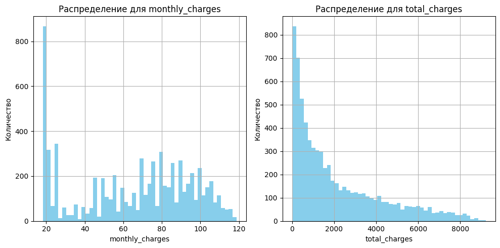

```
========================================

Графики распределения для количественных дискретных столбцов (столбчатые диаграммы):
```

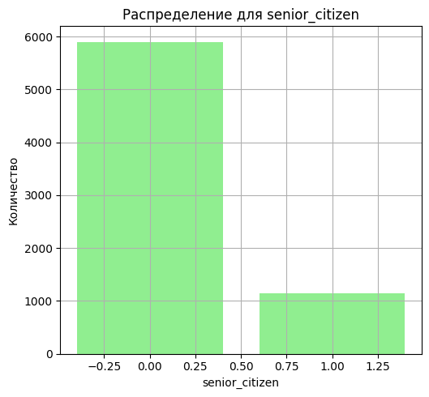

```
========================================

Анализ категориальных столбцов:
--------------------

Столбец: begin_date
Значения, встречающиеся 2 раза и больше:
begin_date
2014-02-01    366
2019-09-01    237
2019-10-01    237
2019-11-01    237
2020-01-01    233
2019-12-01    220
2014-03-01    178
2019-07-01    156
2019-08-01    146
2019-06-01    141
2019-02-01    128
2019-05-01    123
2019-01-01    114
2014-04-01    114
2019-03-01    110
2019-04-01    108
2018-09-01    100
2018-08-01    100
2018-11-01     99
2014-05-01     98
2014-07-01     98
2014-06-01     97
2017-03-01     94
2018-02-01     91
2017-12-01     90
2018-12-01     90
2018-03-01     89
2018-06-01     84
2014-08-01     82
2017-11-01     82
2015-10-01     81
2018-04-01     81
```

[output cut: 272 more lines]

```
Количество уникальных значений: 3
Процент категории "No": 39.54%
Процент категории "Yes": 38.79%
--------------------

Столбец: multiple_lines
Все уникальные значения:
multiple_lines
No            3390
Yes           2971
No package     682
Name: count, dtype: int64
Количество уникальных значений: 3
Процент категории "No": 48.13%
Процент категории "Yes": 42.18%
```

```python
check_data(df, bins=50, figsize=(10, 5))
```

**Промежуточный итог: Загрузка и Предобработка данных**

**Загрузка данных**  
Данные загружены из четырёх источников:

- **`contract_new.csv`** — информация о договорах (7043 строки, 8 столбцов).
- **`personal_new.csv`** — персональные данные клиентов (7043 строки, 5 столбцов).
- **`internet_new.csv`** — данные об интернет-услугах (5517 строк, 8 столбцов).
- **`phone_new.csv`** — информация о телефонных услугах (6361 строка, 2 столбца).

Все датасеты объединены по ключу `customer_id` с использованием метода `inner/outer join`, чтобы сохранить только актуальные записи.

## Исследовательский и Корреляционный анализ данных

```python
# Функция для исследовательского анализа числовых признаков
def number_columns(data, column, bins=50):

    # Описательная статистика
    description = data[column].describe()
    print(f"\n=== Описательная статистика для '{column}' ===")
    print(description)

    # Проверка на выбросы с использованием IQR
    Q1 = data[column].quantile(0.25)
    Q3 = data[column].quantile(0.75)
    IQR = Q3 - Q1
    lower_bound = Q1 - 1.5 * IQR
    upper_bound = Q3 + 1.5 * IQR

    outliers = data[(data[column] < lower_bound) | (data[column] > upper_bound)]
    print(f"\nКоличество выбросов в '{column}': {len(outliers)}")

    # Построение гистограммы и boxplot
    fig, ax = plt.subplots(1, 2, figsize=(15, 6))

    sns.histplot(x=data[column], kde=True, ax=ax[0], bins=bins, color='skyblue')
    ax[0].set_title(f'Гистограмма для {column}')
    ax[0].set_xlabel(column)
    ax[0].set_ylabel('Частота')

    sns.boxplot(x=data[column], ax=ax[1], color='lightgreen')
    ax[1].set_title(f'Boxplot для {column}')
    ax[1].set_xlabel(column)

    plt.tight_layout()
    plt.show()
```

```python
def categorical_columns(data):
    # Определяем категориальные признаки
    categorical_columns = data.select_dtypes(include=['object', 'category']).columns.tolist()

    # Создаём подграфики
    num_plots = len(categorical_columns)
    rows = (num_plots + 2) // 3
    fig, axs = plt.subplots(rows, 3, figsize=(18, 5 * rows))
    axs = axs.flatten()

    # Генерируем круговые диаграммы
    for i, column in enumerate(categorical_columns):
        # Подсчёт частот категорий
        value_counts = data[column].value_counts()

        # Рисуем круговую диаграмму
        total = value_counts.sum()  # Общее количество записей для столбца
        axs[i].pie(
            value_counts,
            labels=value_counts.index,
            autopct=lambda pct: f'{pct:.1f}% ({int(pct/100.*total)})',  # Проценты и абсолютные значения
            startangle=90
        )
        axs[i].set_title(column)  # Устанавливаем заголовок графика

    # Удаляем пустые оси, если их больше, чем диаграмм
    for j in range(i + 1, len(axs)):
        fig.delaxes(axs[j])

    plt.tight_layout()
    plt.show()
```

### Построение графиков для анализа

```python
df.info()
```

```
<class 'pandas.core.frame.DataFrame'>
Index: 7043 entries, 7590-VHVEG to 3186-AJIEK
Data columns (total 19 columns):
 #   Column             Non-Null Count  Dtype
---  ------             --------------  -----
 0   begin_date         7043 non-null   datetime64[ns]
 1   end_date           7043 non-null   object
 2   type               7043 non-null   object
 3   paperless_billing  7043 non-null   object
 4   payment_method     7043 non-null   object
 5   monthly_charges    7043 non-null   float64
 6   total_charges      7043 non-null   float64
 7   gender             7043 non-null   object
 8   senior_citizen     7043 non-null   int64
 9   partner            7043 non-null   object
 10  dependents         7043 non-null   object
 11  internet_service   7043 non-null   object
 12  online_security    7043 non-null   object
 13  online_backup      7043 non-null   object
 14  device_protection  7043 non-null   object
 15  tech_support       7043 non-null   object
 16  streaming_tv       7043 non-null   object
 17  streaming_movies   7043 non-null   object
 18  multiple_lines     7043 non-null   object
dtypes: datetime64[ns](1), float64(2), int64(1), object(15)
memory usage: 1.3+ MB
```

```python
cat_columns = ['type', 'paperless_billing', 'payment_method', 'gender', 'partner', 'dependents',
               'internet_service', 'online_security', 'online_backup', 'device_protection', 'tech_support']
```

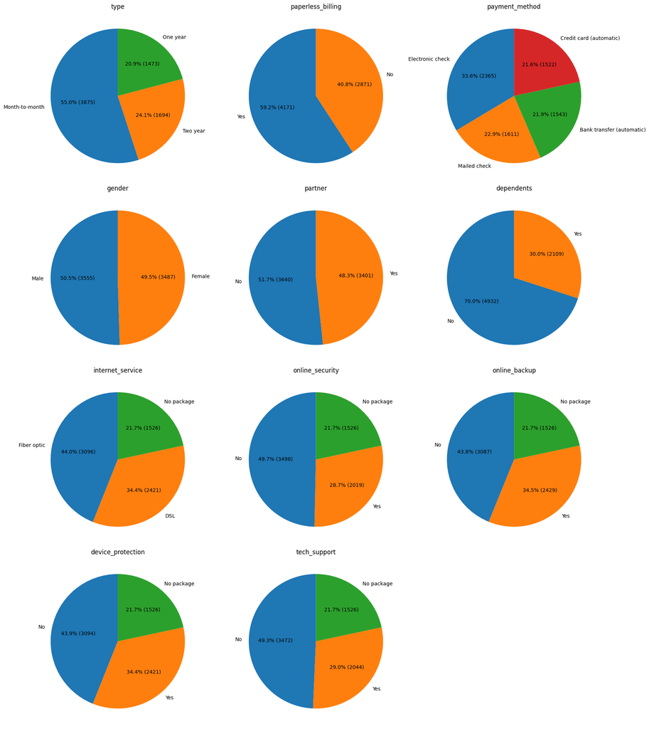

```python
categorical_columns(df[cat_columns])
```

```python
print(f'Всего уникальных значений в столбце df["begin_date"]: {df["begin_date"].nunique()}\n')
display(df.begin_date.value_counts().head()) # Вывод самых частых категорий
print()
ttl_cnt = len(df['begin_date'])
for ctgr, cnt in df['begin_date'].value_counts().head(2).items():
    prcntg = (cnt / ttl_cnt) * 100
    print(f'Процент категории "{ctgr}": {prcntg:.2f}%')
```

```
Всего уникальных значений в столбце df["begin_date"]: 77
```

| begin_date | count |
| --- | --- |
| 2014-02-01 | 366 |
| 2019-09-01 | 237 |
| 2019-10-01 | 237 |
| 2019-11-01 | 237 |
| 2020-01-01 | 233 |

**dtype:** int64

```
Процент категории "2014-02-01 00:00:00": 5.20%
Процент категории "2019-09-01 00:00:00": 3.37%
```

```python
print(f'Всего уникальных значений в столбце df["end_date"]: {df["end_date"].nunique()}\n')
display(df.end_date.value_counts().head()) # Вывод самых частых категорий
print()

# Процент для "No"
no_count = df['end_date'].value_counts().get('No', 0)  # Количество для "No"
# Процент для всех остальных категорий
others_count = len(df['end_date']) - no_count  # Количество всех записей, кроме "No"

print(f'Процент категории "No": {(no_count / ttl_cnt) * 100:.2f}%')
print(f'Процент всех остальных категорий: {(others_count / ttl_cnt) * 100:.2f}%')
```

```
Всего уникальных значений в столбце df["end_date"]: 67
```

| end_date | count |
| --- | --- |
| No | 5942 |
| 2020-01-01 | 39 |
| 2019-12-01 | 38 |
| 2018-11-01 | 35 |
| 2019-09-01 | 32 |

**dtype:** int64

```
Процент категории "No": 84.37%
Процент всех остальных категорий: 15.63%
```

- `begin_date` - дата начала договора, чаще всего встречается значение 2014-02-01 (5,20%) и 2019-09-01 (3.37%), что может говорить о слабом удержании преданных клиетов.
- `end_date` - 84,4% абонентов, являются действующими пользователями услуг, 15,63% пользователей не продлили договор.
- `type` - большенство пользователей предпочитают платить за услуги ежимесячно 55,0%.
- `paperless_billing` - 59,2% хотят получать чеки.
- `payment_method` - методы оплаты распределены почти поровну, наиболее популярен способ платежа - электронный чек (33,6%).
- `gender` - почти равное распределение мужчин 50,5% и женщин 49,5%.
- `partner` - почти равное соотношение абонентов с партнером 48,3% и без 51.7%.
- `dependents` - 70% клиентов не имеют детей, 30% — имеют.
- `internet_sevice` - 44% используют оптоволоконный интернет (Fiber optic).
- `online_security, online_backup, device_protection, tech_support` - у всех этих услуг примерно одинаковое распределение, около 40–50% клиентов не пользуются услугой, 29–35% - пользуются, у 21,7% - не подключен данная услуга.

```
=== Описательная статистика для 'monthly_charges' ===
count    7043.000000
mean       64.761692
std        30.090047
min        18.250000
25%        35.500000
50%        70.350000
75%        89.850000
max       118.750000
Name: monthly_charges, dtype: float64

Количество выбросов в 'monthly_charges': 0
```

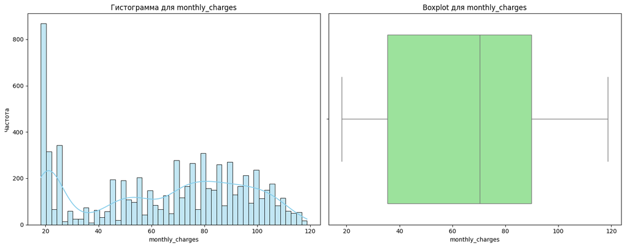

```python
number_columns(df, 'monthly_charges')
```

```
=== Описательная статистика для 'total_charges' ===
count    7043.000000
mean     2115.312885
std      2112.742814
min         0.000000
25%       436.750000
50%      1343.350000
75%      3236.690000
max      9221.380000
Name: total_charges, dtype: float64

Количество выбросов в 'total_charges': 195
```

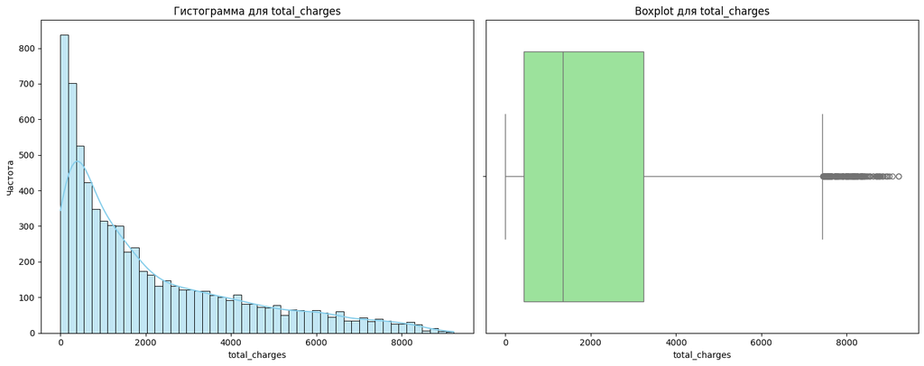

```python
number_columns(df, 'total_charges')
```

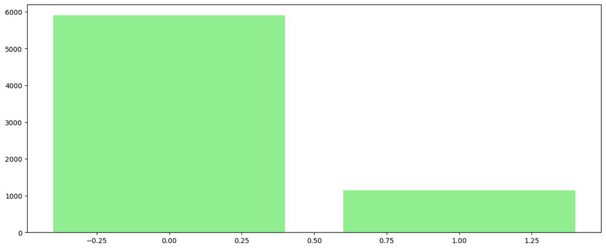

```python
plt.figure(figsize=(15, 6))
plt.bar(df['senior_citizen'].value_counts().index, df['senior_citizen'].value_counts().values,  color='lightgreen')
plt.show()
```

```python
print(f'Всего уникальных значений в столбце df["senior_citizen"]: {df["senior_citizen"].nunique()}\n')
display(df.senior_citizen.value_counts().head()) # Вывод самых частых категорий
print()
ttl_cnt = len(df['senior_citizen'])
for ctgr, cnt in df['senior_citizen'].value_counts().head(2).items():
    prcntg = (cnt / ttl_cnt) * 100
    print(f'Процент категории "{ctgr}": {prcntg:.2f}%')
```

```
Всего уникальных значений в столбце df["senior_citizen"]: 2
```

| senior_citizen | count |
| --- | --- |
| 0 | 5901 |
| 1 | 1142 |

**dtype:** int64

```
Процент категории "0": 83.79%
Процент категории "1": 16.21%
```

График признака `senior_citizen` представляет собой бинарное распределение (принимает значения 0 и 1). 16,21% пользоваетлей компании являются пенсионерами.

### Корреляционный анализ

Для точного корреляционного анализа, создадим новые признаки. Из признака `end_date` выделим целовой признак `client`, посчитав разницу между днем заключения договора и `end_date` создадим признак длительность контракта `duration_days`.

```python
df.head()
```

| customer_id | begin_date | end_date | type | paperless_billing | payment_method | monthly_charges | total_charges | gender | senior_citizen | partner | dependents | internet_service | online_security | online_backup | device_protection | tech_support | streaming_tv | streaming_movies | multiple_lines |
| --- | --- | --- | --- | --- | --- | --- | --- | --- | --- | --- | --- | --- | --- | --- | --- | --- | --- | --- | --- |
| 7590-VHVEG | 2020-01-01 | No | Month-to-month | Yes | Electronic check | 29.85 | 31.04 | Female | 0 | Yes | No | DSL | No | Yes | No | No | No | No | No package |
| 5575-GNVDE | 2017-04-01 | No | One year | No | Mailed check | 56.95 | 2071.84 | Male | 0 | No | No | DSL | Yes | No | Yes | No | No | No | No |
| 3668-QPYBK | 2019-10-01 | No | Month-to-month | Yes | Mailed check | 53.85 | 226.17 | Male | 0 | No | No | DSL | Yes | Yes | No | No | No | No | No |
| 7795-CFOCW | 2016-05-01 | No | One year | No | Bank transfer (automatic) | 42.30 | 1960.60 | Male | 0 | No | No | DSL | Yes | No | Yes | Yes | No | No | No package |
| 9237-HQITU | 2019-09-01 | No | Month-to-month | Yes | Electronic check | 70.70 | 353.50 | Female | 0 | No | No | Fiber optic | No | No | No | No | No | No | No |

Создадим столбец с помощью которого и выполним расчет, длительности договора.

```python
client = df['end_date'].apply(lambda x: '2020-02-01' if x == 'No' else x)
df['duration_days'] = (pd.to_datetime(client, errors='coerce', format='%Y-%m-%d') - df['begin_date']).dt.days
```

Создадим в датасете целевой признак `client`, где 0 - у абонента есть дествущий договор.

```python
df['client'] = df['end_date'].apply(lambda x: 0 if x == 'No' else 1)
df.head()
```

| customer_id | begin_date | end_date | type | paperless_billing | payment_method | monthly_charges | total_charges | gender | senior_citizen | partner | dependents | internet_service | online_security | online_backup | device_protection | tech_support | streaming_tv | streaming_movies | multiple_lines | duration_days | client |
| --- | --- | --- | --- | --- | --- | --- | --- | --- | --- | --- | --- | --- | --- | --- | --- | --- | --- | --- | --- | --- | --- |
| 7590-VHVEG | 2020-01-01 | No | Month-to-month | Yes | Electronic check | 29.85 | 31.04 | Female | 0 | Yes | No | DSL | No | Yes | No | No | No | No | No package | 31 | 0 |
| 5575-GNVDE | 2017-04-01 | No | One year | No | Mailed check | 56.95 | 2071.84 | Male | 0 | No | No | DSL | Yes | No | Yes | No | No | No | No | 1036 | 0 |
| 3668-QPYBK | 2019-10-01 | No | Month-to-month | Yes | Mailed check | 53.85 | 226.17 | Male | 0 | No | No | DSL | Yes | Yes | No | No | No | No | No | 123 | 0 |
| 7795-CFOCW | 2016-05-01 | No | One year | No | Bank transfer (automatic) | 42.30 | 1960.60 | Male | 0 | No | No | DSL | Yes | No | Yes | Yes | No | No | No package | 1371 | 0 |
| 9237-HQITU | 2019-09-01 | No | Month-to-month | Yes | Electronic check | 70.70 | 353.50 | Female | 0 | No | No | Fiber optic | No | No | No | No | No | No | No | 153 | 0 |

```python
df.describe()
```

|  | begin_date | monthly_charges | total_charges | senior_citizen | duration_days | client |
| --- | --- | --- | --- | --- | --- | --- |
| count | 7043 | 7043.000000 | 7043.000000 | 7043.000000 | 7043.000000 | 7043.000000 |
| mean | 2017-04-30 13:01:50.918642688 | 64.761692 | 2115.312885 | 0.162147 | 898.555729 | 0.156325 |
| min | 2013-10-01 00:00:00 | 18.250000 | 0.000000 | 0.000000 | 0.000000 | 0.000000 |
| 25% | 2015-06-01 00:00:00 | 35.500000 | 436.750000 | 0.000000 | 276.000000 | 0.000000 |
| 50% | 2017-09-01 00:00:00 | 70.350000 | 1343.350000 | 0.000000 | 761.000000 | 0.000000 |
| 75% | 2019-04-01 00:00:00 | 89.850000 | 3236.690000 | 0.000000 | 1461.000000 | 0.000000 |
| max | 2020-02-01 00:00:00 | 118.750000 | 9221.380000 | 1.000000 | 2314.000000 | 1.000000 |
| std | NaN | 30.090047 | 2112.742814 | 0.368612 | 683.130510 | 0.363189 |

Посмтроим матрицу корреляция и определим взяимосвязь между всеми признаками.

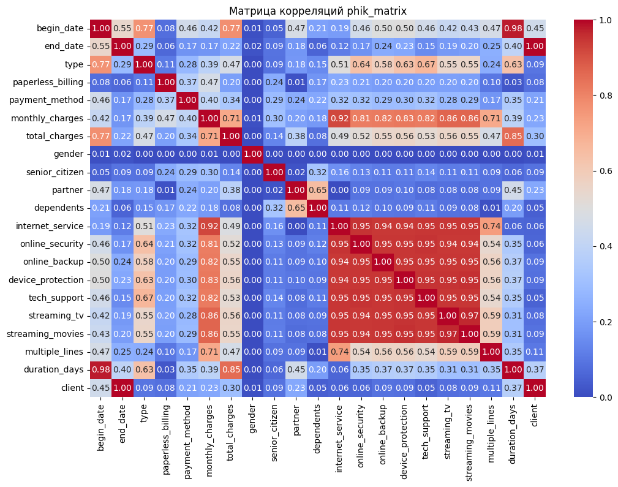

```python
# Числовые признаки для interval_cols
interval_cols = ['monthly_charges', 'total_charges', 'duration_days']

# Визуализация матрицы корреляции
plt.figure(figsize=(12, 8))
sns.heatmap(df.phik_matrix(interval_cols=interval_cols), annot=True, fmt='.2f', cmap='coolwarm')
plt.title('Матрица корреляций phik_matrix')
plt.show()
```

На основе анализа матрицы корреляции phik можно сделать следующие выводы относительно целевой переменной `client`:

**Сильные корреляции с переменной `client` у:**

- `end_date`: 1,00 (ожидаемо, так как `client` получена из `end_date`)
- `begin_date`: 0,45 — дата начала контракта имеет умеренную связь с оттоком
- `duration_days`: 0,37 — продолжительность обслуживания клиента связана с оттоком

**Умеренные корреляции:**

- `total_charges`: 0,30 — общая сумма платежей
- `partner`: 0,23 — наличие партнёра
- `monthly_charges`: 0,23 — ежемесячные платежи
- `payment_method`: 0,21 — способ оплаты

**Слабые связи с оттоком:**  
Большинство дополнительных услуг и персональных характеристик показывают слабую корреляцию с оттоком клиентов (0,01-0,11):

- Тип оплаты, также практически не влияет на `client`.
- Получение чека `paperless_billing` не влияет на `client`.
- Пол клиента практически не влияет на отток (0,01).
- Признаки `senior_citizen` и `dependents` также слабо влияют на отток (0,05-0,09)
- Интернет-услуги и дополнительные сервисы имеют минимальное влияние.

**Мультиколлинеарность между предикторами**  
Дополнительные услуги (`online_security`, `online_backup`, `device_protection`, `tech_support`, `streaming_tv`, `streaming_movies`) имеют чрезвычайно высокие корреляции друг с другом (0,94-0,97). Это указывает на серьёзную мультиколлинеарность.

Нужно выполнить объединение дополнительных услуг из-за мультиколлинеарност. Также следует удалить признаки, слабо коррелирующие с целевой переменной `client`.

```python
services = df.loc[:,'online_security':'streaming_movies'].apply(lambda x: (x == 'Yes').sum(), axis=1)
df.insert(loc=len(df.columns) - 1, column='services', value=services)
```

```python
columns_to_drop = df.loc[:, 'online_security':'streaming_movies'].columns.tolist()
columns_to_drop.extend(['begin_date', 'end_date', 'type', 'paperless_billing', 'gender', 'senior_citizen', 'dependents']) # Добавляем остальные столбцы для удаления
df = df.drop(columns=columns_to_drop, axis=1)
df.head()
```

| customer_id | payment_method | monthly_charges | total_charges | partner | internet_service | multiple_lines | duration_days | services | client |
| --- | --- | --- | --- | --- | --- | --- | --- | --- | --- |
| 7590-VHVEG | Electronic check | 29.85 | 31.04 | Yes | DSL | No package | 31 | 1 | 0 |
| 5575-GNVDE | Mailed check | 56.95 | 2071.84 | No | DSL | No | 1036 | 2 | 0 |
| 3668-QPYBK | Mailed check | 53.85 | 226.17 | No | DSL | No | 123 | 2 | 0 |
| 7795-CFOCW | Bank transfer (automatic) | 42.30 | 1960.60 | No | DSL | No package | 1371 | 3 | 0 |
| 9237-HQITU | Electronic check | 70.70 | 353.50 | No | Fiber optic | No | 153 | 0 | 0 |

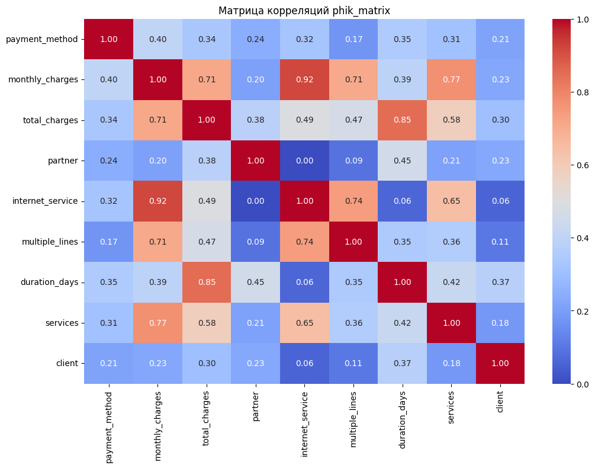

```python
# Визуализация матрицы корреляции
plt.figure(figsize=(12, 8))
sns.heatmap(df.phik_matrix(interval_cols=interval_cols), annot=True, fmt='.2f', cmap='coolwarm')
plt.title('Матрица корреляций phik_matrix')
plt.show()
```

```python
df.info()
```

```
<class 'pandas.core.frame.DataFrame'>
Index: 7043 entries, 7590-VHVEG to 3186-AJIEK
Data columns (total 9 columns):
 #   Column            Non-Null Count  Dtype
---  ------            --------------  -----
 0   payment_method    7043 non-null   object
 1   monthly_charges   7043 non-null   float64
 2   total_charges     7043 non-null   float64
 3   partner           7043 non-null   object
 4   internet_service  7043 non-null   object
 5   multiple_lines    7043 non-null   object
 6   duration_days     7043 non-null   int64
 7   services          7043 non-null   int64
 8   client            7043 non-null   int64
dtypes: float64(2), int64(3), object(4)
memory usage: 808.3+ KB
```

**Промежуточный итог: Исследовательский и корреляционный анализ данных**

**На отток клиентов влияет:**

- **Дата заключения договора** (`begin_date`), **длительность контракта** (`duration_days`) и **общие расходы** (`total_charges`) имеют умеренную положительную корреляцию с оттоком. Это может указывать на то, что долгосрочные клиенты склонны уходить чаще, чем новые.
- **Ежемесячные расходы** (`monthly_charges`) и **способ оплаты** (`payment_method`) также влияют на отток (корреляция ~0,23).
- **Наличие партнера** (`partner`) имеет умеренную связь с лояльностью клиентов (корреляция 0,23).

## Обучение модели

Выделим обучающую и тестовую выборку.

```python
X = df.drop('client', axis=1)
y = df['client']
# используем стратификацию для сохранения соотношения классов
X_train, X_test, y_train, y_test = train_test_split(X, y, test_size=0.25, stratify=y, random_state=RANDOM_STATE)
```

```python
display(X_train.shape)
display(y_train.shape)
display(X_test.shape)
display(y_test.shape)
```

```
(5282, 8)
```

```
(5282,)
```

```
(1761, 8)
```

```
(1761,)
```

```python
X_train.info()
```

```
<class 'pandas.core.frame.DataFrame'>
Index: 5282 entries, 8773-HHUOZ to 9479-HYNYL
Data columns (total 8 columns):
 #   Column            Non-Null Count  Dtype
---  ------            --------------  -----
 0   payment_method    5282 non-null   object
 1   monthly_charges   5282 non-null   float64
 2   total_charges     5282 non-null   float64
 3   partner           5282 non-null   object
 4   internet_service  5282 non-null   object
 5   multiple_lines    5282 non-null   object
 6   duration_days     5282 non-null   int64
 7   services          5282 non-null   int64
dtypes: float64(2), int64(2), object(4)
memory usage: 371.4+ KB
```

```python
# Создаём списки с названиями признаков
ohe_columns = ['payment_method', 'partner', 'internet_service', 'multiple_lines']  # Признаки без иерархии
num_columns = ['monthly_charges', 'total_charges', 'duration_days', 'services']  # Числовые признаки
```

```python
# Пайплайн для OHE-кодирования
ohe_pipe = Pipeline(
    [
        (
            'simpleImputer_ohe',
            SimpleImputer(missing_values=np.nan, strategy='most_frequent')
        ),
        (
            'ohe',
            OneHotEncoder(drop='first', handle_unknown='ignore', sparse_output=False)
        )
    ]
)
```

```python
# Общая подготовка данных
data_preprocessor = ColumnTransformer(
    [
        ('ohe', ohe_pipe, ohe_columns),
        ('num', MinMaxScaler(), num_columns)
    ],
    remainder='passthrough'
)
```

```python
# Итоговый пайплайн
pipe_final = Pipeline(
    [
        ('preprocessor', data_preprocessor),
        ('model', DecisionTreeClassifier(random_state=RANDOM_STATE))
    ]
)
```

```python
# Словарь с моделями и их гиперпараметрами для RandomizedSearchCV
param_grid = [
    # Словарь для модели DecisionTreeRegressor()
    {
        'model': [DecisionTreeClassifier(random_state=RANDOM_STATE)],
        'model__max_depth': [None, 10, 20, 30],
        'model__min_samples_split': [5, 10, 15],
        'preprocessor__num': [MinMaxScaler(), StandardScaler(), 'passthrough']
    },

    # Словарь для модели LinearRegression()
    {
        'model': [LogisticRegression(random_state=RANDOM_STATE)],
        'model__C': [0.1, 1, 10],
        'model__penalty': ['l1', 'l2'],
        'model__solver': ['liblinear'],
        'preprocessor__num': [MinMaxScaler(), StandardScaler(), 'passthrough']
    },

    # Словарь для модели CatBoostRegressor()
    {
        'model': [CatBoostClassifier(verbose=0, random_state=RANDOM_STATE)],
        'model__depth': [2, 6, 8],
        'model__iterations': [100, 500],
        'model__learning_rate': [0.01, 0.05, 0.1, 0.15],
        'preprocessor__num': ['passthrough']
    }
]
```

```python
randomized_search = RandomizedSearchCV(
    pipe_final,
    param_grid,
    cv=5,
    scoring='roc_auc',
    n_iter=15,  # Количество случайных комбинаций
    random_state=RANDOM_STATE,
    n_jobs=-1
)
randomized_search.fit(X_train, y_train)
```

```
RandomizedSearchCV(cv=5,
                   estimator=Pipeline(steps=[('preprocessor',
                                              ColumnTransformer(remainder='passthrough',
                                                                transformers=[('ohe',
                                                                               Pipeline(steps=[('simpleImputer_ohe',
                                                                                                SimpleImputer(strategy='most_frequent')),
                                                                                               ('ohe',
                                                                                                OneHotEncoder(drop='first',
                                                                                                              handle_unknown='ignore',
                                                                                                              sparse_output=False))]),
                                                                               ['payment_method',
                                                                                'partner',
                                                                                'internet_service',
                                                                                'multiple_line...
                                         'model__penalty': ['l1', 'l2'],
                                         'model__solver': ['liblinear'],
                                         'preprocessor__num': [MinMaxScaler(),
                                                               StandardScaler(),
                                                               'passthrough']},
                                        {'model': [<catboost.core.CatBoostClassifier object at 0x7e9179db5890>],
                                         'model__depth': [2, 6, 8],
                                         'model__iterations': [100, 500],
                                         'model__learning_rate': [0.01, 0.05,
                                                                  0.1, 0.15],
                                         'preprocessor__num': ['passthrough']}],
                   random_state=20625, scoring='roc_auc')
```

```python
print("Лучшие параметры CatBoostRegressor:", randomized_search.best_params_)
```

```
Лучшие параметры CatBoostRegressor: {'preprocessor__num': 'passthrough', 'model__learning_rate': 0.1, 'model__iterations': 500, 'model__depth': 6, 'model': <catboost.core.CatBoostClassifier object at 0x7e9179db5890>}
```

```python
best_cv_roc_auc = randomized_search.best_score_
print(f'Метрика roc_auc, для модели CatBoostRegressor на кросс-валидации: {best_cv_roc_auc:.2f}')
```

```
Метрика roc_auc, для модели CatBoostRegressor на кросс-валидации: 0.91
```

Значение `roc_auc` на кросс-валидации выше требуемого порогового значения метрики 0,91 > 0,85.

```python
best_model = randomized_search.best_estimator_
```

```python
y_pred = best_model.predict_proba(X_test)[:, 1]
test_roc_auc = roc_auc_score(y_test, y_pred)
print(f"roc_auc на тестовой выборке для лучшей модели: {test_roc_auc:.2f}")
```

```
roc_auc на тестовой выборке для лучшей модели: 0.90
```

```python
y_pred_acc = best_model.predict(X_test)
test_acc = accuracy_score(y_test, y_pred_acc)
print(f"Accuracy на тестовой выборке: {test_acc:.2f}")
```

```
Accuracy на тестовой выборке: 0.92
```

**Промежуточный итог: Обучение модели**

**Результаты метрик**

- **ROC AUC на кросс-валидации:**
  - Значение метрики: **0,91**.
  - Это превышает пороговое значение 0,85, что подтверждает высокую способность модели различать классы.
- **ROC AUC на тестовой выборке:**
  - Значение метрики: **0,90**.
  - Модель сохраняет высокую качество на новых данных.
- **Accuracy на тестовой выборке:**
  - Значение метрики: **0,92**.

**Анализ и интерпретация метрик**

- **ROC AUC (0,90):**
  - Показатель близкий к 1 говорит о том, что модель отлично справляется с разделением клиентов на, которые уйдут, и те, кто останется.
  - Учитывая дисбаланс классов (84% остаются, 16% уходят), ROC AUC является корректной метрикой, так как учитывает все классы.
- **Accuracy (0,92):**
  - Модель правильно классифицирует 92% всех случаев.
  - Однако из-за дисбаланса классов (преобладание "оставшихся" клиентов) эта метрика может быть обманчивой. Например, если модель всегда предсказывает "остался", accuracy будет ~84%, что близко к текущему значению.
- **Эффективность модели:**
  - CatBoost показал высокое качество прогнозирования (ROC AUC = 0.90).
  - Модель способна выявлять склонных к оттоку клиентов с высокой точностью.
- **Ограничения:**
  - Accuracy (0.92) не отражает полной картины из-за дисбаланса классов.
  - Требуется дополнительный анализ матрицы ошибок для оценки ошибок первого и второго рода (например, сколько ушедших клиентов модель правильно определила).

**Дальнейшие шаги**

- Исследовать важность признаков с помощью `feature_importances_` для CatBoost.
- Построить **матрицу ошибок** для детальной интерпретации результатов ложноположительные (FP) или ложноотрицательные (FN) ошибки.

## Интерпретация важности признаков

```python
# Получаем названия признаков
ohe_features = best_model.named_steps['preprocessor'].named_transformers_['ohe'].get_feature_names_out(ohe_columns)
all_features = np.concatenate([ohe_features, num_columns])
# Извлечение важности признаков
importances = best_model.named_steps['model'].feature_importances_
```

```python
# Создаем DataFrame для визуализации
feature_names = X_train.columns
feature_importance_df = pd.DataFrame({'feature': all_features, 'importance': importances}).sort_values(by='importance', ascending=False)
```

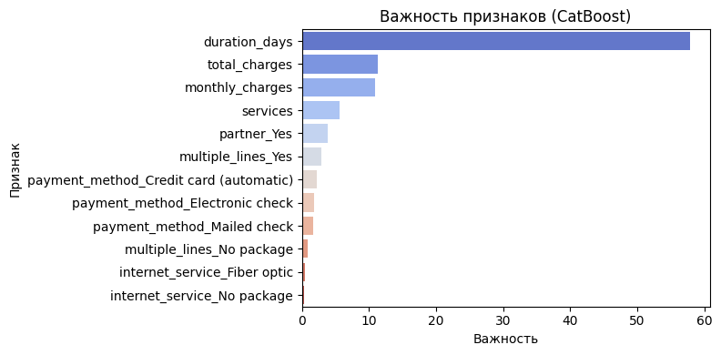

```python
# Визуализация
plt.figure(figsize=(8, 4))
sns.barplot(x='importance', y='feature', data=feature_importance_df, hue='feature', palette='coolwarm', legend=False)
plt.title('Важность признаков (CatBoost)')
plt.xlabel('Важность')
plt.ylabel('Признак')
plt.tight_layout()
plt.show()
```

**Промежуточный итог: Интерпретация важности признаков**

На основе анализа графика важности признаков модели CatBoost можно сделать следующие выводы:

**Наиболее важные признаки**

- **`duration_days`**:  
  **Продолжительность контракта** является **самым влиятельным фактором** оттока клиентов. Клиенты с длительным стажем, вероятно, сталкиваются с устаревшими тарифами или снижением удовлетворённости сервисом, что увеличивает риск расторжения договора.
- **`total_charges`** и **`monthly_charges`**:  
  **Общая сумма платежей** и **ежемесячные расходы** также играют ключевую роль. Высокие затраты могут быть основной причиной недовольства клиентов, особенно если качество услуг не соответствует цене.
- **`services`**:  
  **Количество подключенных дополнительных услуг** (антивирус, стриминг, техподдержка) слабо, но положительно коррелирует с лояльностью. Клиенты, использующие больше услуг, реже уходят.
- **`partner_Yes`** и **`multiple_lines_Yes`**:  
  Наличие партнёра или подключения к нескольким телефонным линиям имеет незначительное, но заметное влияние. Это может указывать на то, что семейные клиенты или те, кто использует расширенные услуги связи, более устойчивы к оттоку.

**Малозначимые признаки**

- **Категориальные признаки** (`payment_method`, `internet_service`, `multiple_lines`) после OHE-кодирования имеют **очень низкую важность**.
- **`internet_service_No package` и `multiple_lines_No package`**:  
  Отсутствие услуг интернета или телефонии почти не влияет на отток.

**Рекомендации для бизнеса**

- Снижение ежемесячных платежей или введение гибких условий для долгосрочных клиентов должно помочь справиться с их оттоком. Также можено вести программу лояльности, для таких клиетво (например, бонусы за годичную выслугу).
- Предоставление скидок для абонентов с высокими накопленными расходами.
- Внедряйте персонализированные предложения для групп риска (например, клиенты коротким стажем).

**Итог**  
Модель CatBoost выявила, что **финансовые параметры** (`duration_days`, `total_charges`, `monthly_charges`) и **количество услуг** (`services`) являются ключевыми факторами оттока.

## Интерпретация матрицы ошибок

Построим матрицу ошибок, чтобы понять как ошибалась модель.

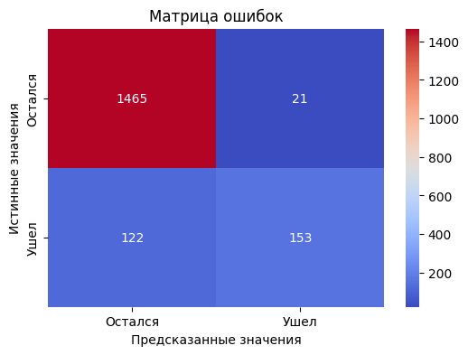

```python
# Вычисление матрицы ошибок
cm = confusion_matrix(y_test, np.round(y_pred))

# Визуализация матрицы
plt.figure(figsize=(6, 4))
sns.heatmap(cm, annot=True, fmt='d', cmap='coolwarm', xticklabels=['Остался', 'Ушел'], yticklabels=['Остался', 'Ушел'])
plt.xlabel('Предсказанные значения')
plt.ylabel('Истинные значения')
plt.title('Матрица ошибок')
plt.show()
```

**Интерпретация матрицы ошибок**

**Матрица ошибок** позволяет оценить качество модели путём анализа четырёх ключевых компонент:

1. **True Negatives (TN = 1465)**:  
   Модель правильно определила **1465 клиентов**, которые не собирались уходить. Это подтверждает её способность минимизировать ложные срабатывания для класса "остался".
2. **False Positives (FP = 21)**:  
   **21 клиент**, который остался, был ошибочно классифицирован как "ушедший". Хотя это небольшое количество, такая ошибка может привести к лишним затратам на удержание (например, промокоды для лояльных клиентов).
3. **False Negatives (FN = 122)**:  
   **122 клиента**, которые ушли, не были выявлены моделью. Это критичная ошибка, так как компания не смогла своевременно предложить меры удержания, что требует улучшения.
4. **True Positives (TP = 153)**:  
   Модель верно идентифицировала **153 ушедшего клиента**, что является хорошим результатом, но FN снижает общий показатель полноты.

**Выводы и рекомендации**  
Модель недостаточно чувствительна к оттоку (**FN**). Для улучшения recall можно:

- Оптимизировать порог классификации, снизить его.
- Использовать методы борьбы с дисбалансом.

## **Итоговые выводы**

**Описание проекта**  
Проект был выполнен для телекоммуникационного оператора **«ТелеДом»**, сталкивающегося с проблемой оттока клиентов. Компания стремилась минимизировать убытки за счет внедрения **системы персонализированных предложений** (скидки, промокоды, специальные условия) для клиентов, склонных к расторжению договора.

**Цель проекта**  
Задача заключалась в разработке модели машинного обучения, которая:

1. Предсказывает вероятность оттока клиентов.
2. Идентифицирует ключевые факторы, влияющие на уход клиентов.
3. Позволяет принимать меры по удержанию абонентов.

**Рекомендации для бизнеса**

1. **Оптимизация тарифов и условий**
   - Снижение ежемесячных платежей для клиентов с высокими `monthly_charges`.
   - Введение программ лояльности для долгосрочных клиентов (например, бонусы за годичную выслугу).
2. **Улучшение удержания через дополнительные услуги**
   - Поощрение подключения услуг (антивирус, стриминг) скидками или пакетными предложениями.
   - Анализ FN-клиентов для выявления скрытых причин оттока.
3. **Персонализированные предложения**
   - Таргетирование групп риска: клиенты с высокими затратами, коротким стажем, минимальным количеством услуг.